```python
%load_ext autoreload
%autoreload 2
%matplotlib inline

import healpy as hp
import pysm
import pylab as pl
from fgbuster.observation_helpers import get_instrument, get_sky
from fgbuster.component_model import CMB, Dust, Synchrotron
from fgbuster.visualization import corner_norm

from fgbuster.separation_recipies import basic_comp_sep,adaptive_weighted_comp_sep
#from fgbuster.xForecast import _get_Cl_cmb, _get_Cl_noise
from fgbuster.mixingmatrix import MixingMatrix
import multiprocessing as mp
from functools import partial
from fgbuster.algebra import W_dB, _mmm
import sys
from pysm.common import bandpass_convert_units, K_RJ2Jysr, K_CMB2Jysr, convert_units
import os
from pylab import cm
cmap = cm.get_cmap('RdYlBu')
cmap.set_under('w')
cmap2 = cm.get_cmap('tab20b')
cmap2.set_under('w')

from clustering_utils import ClusterData
import warnings
warnings.filterwarnings("ignore")
```

```
The autoreload extension is already loaded. To reload it, use:
  %reload_ext autoreload
```

```python
from IPython.display import HTML

HTML('''<script>
code_show=true;
function code_toggle() {
 if (code_show){
 $('div.input').hide();
 } else {
 $('div.input').show();
 }
 code_show = !code_show
}
$( document ).ready(code_toggle);
</script>
<form action="javascript:code_toggle()"><input type="submit" value="Click here to toggle on/off the raw code."></form>''')
```

# Adaptive multipatch with Clustering methods

Giuseppe Puglisi - (2020/02/07)

in collaboration with Davide Poletti and Josquin Errard

In this posting we briefly summarize several tests performed with `FGbuster` in the branch `adaptive` under development.  
The outline is to check whether implementing patches defined with Clustering methodologies helps or not in decreasing the systematics residuals we see. In [previous posting](http://giuspugl.github.io/reports/report_on_clustering.html) i've shown how to define the patches via clustering methodologies.

In this posting we want to get closer to more realistic case, including a more complete sky model ( with both *thermal dust and synchrotron* with varying spectral indices) and **noise** in the data.

Finally we compare the outputs from two different component separation routines: the one performed within patches defined with Clustering methodologies (assuming spectral parameters constant within each patch), and the simplistic method which fits for one single spectral parameters across the full sky .

```python
nside = 32
sky = pysm.Sky(get_sky(nside, 's1d1'))
instrument = pysm.Instrument(get_instrument('litebird', nside))
freq_map, noise  = instrument.observe(sky, write_outputs=False)
freq_maps     = freq_map + noise
```

```
nu (GHz) | sigma_I (uK_CMB amin) | sigma_P (uK_CMB amin) | FWHM (arcmin)

0040.00 | 25.60 | 36.10 | 00.00
0050.00 | 13.90 | 19.60 | 00.00
0060.00 | 14.33 | 20.20 | 00.00
0068.40 | 08.01 | 11.30 | 00.00
0078.00 | 07.30 | 10.30 | 00.00
0088.50 | 05.96 | 08.40 | 00.00
0100.00 | 04.96 | 07.00 | 00.00
0118.90 | 04.11 | 05.80 | 00.00
0140.00 | 03.33 | 04.70 | 00.00
0166.00 | 04.96 | 07.00 | 00.00
0195.00 | 04.11 | 05.80 | 00.00
0234.90 | 05.67 | 08.00 | 00.00
0280.00 | 06.45 | 09.10 | 00.00
0337.40 | 08.09 | 11.40 | 00.00
0402.10 | 13.90 | 19.60 | 00.00
Instrument attribute 'pixel_indices' not set.
```

## Loading cluster defined patches

For each spectral parameter we perform the clustering analysis to identify patches. This is performed by estimating the *Hellinger* similarity pairwise pixel -by-pixel, the value of the parameter at a given pixel and its uncertainties are required to estimate how *similar* two pixels are. Uncertainties are taken from [Commander Dust map](http://pla.esac.esa.int/pla/aio/product-action?MAP.MAP_ID=COM_CompMap_dust-commander_0256_R2.00.fits). For $\beta_s$ uncertainties are estimated as inversely proportional to the intensity map of the lowest frequency channel. Maps are downgraded at `nside=32`.

Below you can find the maps:

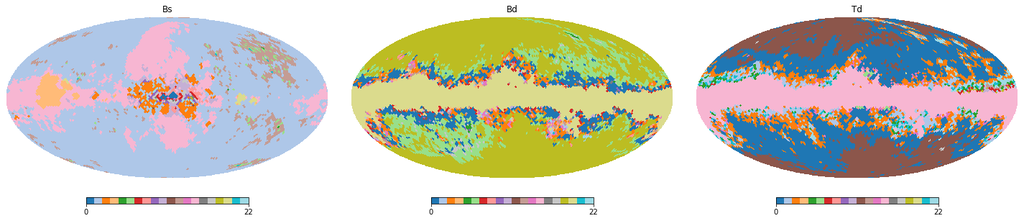

```python
Tdclust= hp.read_map('Patches_combined_Td_32.fits',verbose=False)
Bdclust= hp.read_map('Patches_combined_Bd_32.fits',verbose=False)
Bsclust= hp.read_map('Patches_combined_synch_32.fits',verbose=False)
pl.figure(figsize=(20,7))
hp.mollview(Bsclust, title='Bs' , cmap=pl.cm.tab20  , sub=131)
hp.mollview(Bdclust, title='Bd' , cmap=pl.cm.tab20  , sub=132)
hp.mollview(Tdclust, title='Td' , cmap=pl.cm.tab20  , sub=133)
```

**Fig1** Maps of patches obtained with clustering methodologies .

### Combining multiple cluster maps into one with Pairing functions

So far with FGBuster, is not possible to perform a run with adaptive comp.sep with multiple maps of patches (one per spctral parameters). We therefore have to combine the three maps (in fig.1) into one by means of a *Pairing Function*.

A [Pairing function](https://en.wikipedia.org/wiki/Pairing_function#Cantor_pairing_function) is a process to uniquely encode two natural numbers into a single natural number. Any pairing function can be used in set theory to prove that integers and rational numbers have the same cardinality as natural numbers. In theoretical computer science they are used to encode a function defined on a vector of natural numbers $ f:\mathbb {N} ^{r}\rightarrow \mathbb {N} $ into a new function $ g:\mathbb {N} \rightarrow \mathbb {N} $. In our case $r=2$, i.e. we are looking for a bijection to map $f : \mathbb {N} \times \mathbb {N} \rightarrow \mathbb {N}$. The **Cantor Pairing Function** is essentially what we need, and it's defined as : $$f(n,m) :=\frac{ (n+m )(n+m+1)}{2} + m$$

We therefore define the combined cluster with the Cantor pairing function.

```python
commander = hp.read_map ('/Users/peppe/Downloads/COM_CompMap_dust-commander_0256_R2.00.fits',
                         verbose=False, field=range(9))

ebdpysm = hp.ud_grade( commander[8], nside_out=nside)
Galmask =pl.ma.masked_greater (ebdpysm/ebdpysm.max()  , 0.2 ).mask
Galmask2 =pl.ma.masked_greater (ebdpysm/ebdpysm.max()  , 0.5 ).mask
```

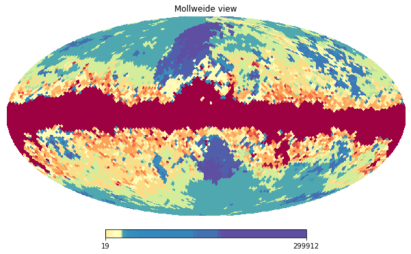

```python
cantor_func = lambda n,m : pl.int_( (n+m )*(n+m+1)/2  + m)

idpatches =cantor_func(Tdclust,cantor_func(Bdclust,Bsclust ))
idpatches[~Galmask]=19
hp.mollview(idpatches, fig=133 , cmap=pl.cm.Spectral, norm='hist')
```

**Fig2** map of clusters combined into one with the Cantor pairing.

## Component separation with adaptive patches

```python
freq_maps[:,:,~Galmask] =hp.UNSEEN
freqs=  pl.array(instrument.Frequencies)
components = [CMB(), Synchrotron(20), Dust(353) ]
#hp.mollview(freq_maps[0,0,:] )
cov =pl.ones_like(freq_maps)
for i in range(freqs.shape[0]):
    cov[i,0,:]*=(instrument.Sens_I[i] )**2/hp.nside2resol(nside, arcmin=True)
    cov[i,1,:]*=(instrument.Sens_P[i] )**2/hp.nside2resol(nside, arcmin=True)
cov[:,2,:]= cov[:,1,:]
```

```python
result   = adaptive_weighted_comp_sep(components, instrument, freq_maps[:,1:] ,cov[:,1:] ,
                                       idpatches)

resultconst   = basic_comp_sep(components, instrument, freq_maps[:,1:] )
```

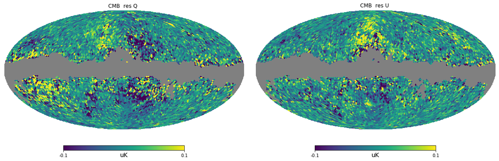

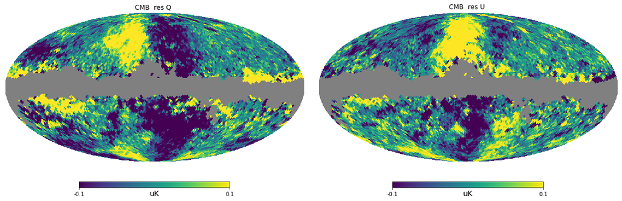

```python
pl.figure(figsize=(16,10 ))

hp.mollview(result.s[0,0] , title='CMB  res Q ', sub=(121), min=-0.1,max=0.1, unit='uK')
hp.mollview(result.s[0,1] , title='CMB  res U ', sub=(122), min=-0.1,max=0.1, unit='uK')


_=pl.figure(figsize=(16,10 ))
hp.mollview(resultconst.s[0,0] , title='CMB  res Q ', sub=(121), min=-0.1,max=0.1, unit='uK')
hp.mollview(resultconst.s[0,1] , title='CMB  res U ', sub=(122), min=-0.1,max=0.1, unit='uK')
```

**Fig3** (top)CMB QU map residuals post component sep. for the run performed with clustering patches. (bottom) CMB QU map residuals post component sep. for the run where one signle spectral parameter has been fitted.

```python
m = pl.zeros_like (freq_maps[0])
mconst = pl.zeros_like (freq_maps[0] )
for i in range(2):
    m[i+1,:] = result.s[0,i]
    mconst[i+1,:] = resultconst .s[0,i]
clconst = hp.anafast(   mconst    ,lmax=3*nside  )
cl = hp.anafast(m   ,lmax=3*nside  )
ell=pl.arange(  cl.shape[1]   )
```

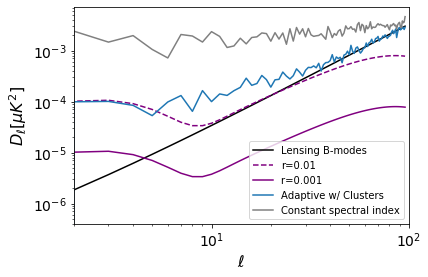

```python
clr = pl.loadtxt('/Users/peppe/work/satellite_sims/power_spectra/Class_planck2015_r0_cl_lensed.dat')
clr1 = pl.loadtxt('/Users/peppe/work/satellite_sims/power_spectra/Class_planck2015_r1_cl_unlensed.dat')
pl.loglog(ell, clr[ :ell.shape[0],3]*ell*( ell +1)/2./pl.pi   ,'k',label='Lensing B-modes'  )
pl.loglog(ell, clr1[ :ell.shape[0],3]*ell*( ell +1)/2./pl.pi /100.  ,'--',color='purple', label='r=0.01'  )
pl.loglog(ell, clr1[ :ell.shape[0],3]*ell*( ell +1)/2./pl.pi /1000.  ,color='purple',label='r=0.001 '  )
pl.loglog(ell, ell*( ell +1)/2./pl.pi* cl[2, :],  label = 'Adaptive w/ Clusters')

pl.loglog(ell, ell*( ell +1)/2./pl.pi* clconst[2, :], color='grey',  label='Constant spectral index')
pl.xlim(2, 100)
pl.ylabel(r'$D_{\ell}  [ \mu K^2 ]$', fontsize=16)
pl.xlabel(r'$ {\ell}   $', fontsize=16)
pl.yticks(fontsize=14)
pl.xticks(fontsize=14)

pl.legend()
#pl.ylim(1e-7, 1e-2)
```

**Fig4** (solid blue) Power spectra of B-mode residuals post component separation performed with adaptive patches. (solid grey) B-mode residuals post-component separation fitting one spectr. parameter constant across the sky.

## Increasing pixels in the map

We can upgrade the map of the patches to a higher `nside`, in order to see what's the leakage at higher multipoles.

In principle, one should obtain the patches from the map of $\beta_d,T_d, \beta_s$ at the `nside` the analysis is done, from that get the optimal number of patches and perform the component separation. However, this is very time consuming being the cluster similarity estimated pairwise, the computational cost is $\mathcal{O}(N_{pix}^2)$.

We therefore upgrade the map of patches (fig.1) at `nside=128` and run fgbuster on maps (signal +noise ) at the same nside .

```python
nside2=128
sky = pysm.Sky(get_sky(nside2, 'd1s1'))
instrument = pysm.Instrument(get_instrument('litebird', nside2))
freq_maps2, noise2 = instrument.observe(sky, write_outputs=False)
freq_mapn2 = freq_maps2 +noise2
idpatches2 =hp.ud_grade(nside_out=nside2 , map_in=idpatches, dtype=pl.int_ )
Galmask3=hp.ud_grade(nside_out=nside2  , map_in=Galmask)
freq_mapn2[:,:,~Galmask3] =hp.UNSEEN

cov =pl.ones_like(freq_maps2)
for i in range(freqs.shape[0]):
    cov[i,0,:]*=(instrument.Sens_I[i] )**2/hp.nside2resol(nside, arcmin=True)
    cov[i,1,:]*=(instrument.Sens_P[i] )**2/hp.nside2resol(nside, arcmin=True)
cov[:,2,:]= cov[:,1,:]
result   = adaptive_weighted_comp_sep(components, instrument, freq_mapn2[:,1:] ,cov[:,1:] ,
                                       idpatches2,options=dict(disp=False))

resultconst   = basic_comp_sep(components, instrument, freq_mapn2[:,1:] )
```

```
nu (GHz) | sigma_I (uK_CMB amin) | sigma_P (uK_CMB amin) | FWHM (arcmin)

0040.00 | 25.60 | 36.10 | 00.00
0050.00 | 13.90 | 19.60 | 00.00
0060.00 | 14.33 | 20.20 | 00.00
0068.40 | 08.01 | 11.30 | 00.00
0078.00 | 07.30 | 10.30 | 00.00
0088.50 | 05.96 | 08.40 | 00.00
0100.00 | 04.96 | 07.00 | 00.00
0118.90 | 04.11 | 05.80 | 00.00
0140.00 | 03.33 | 04.70 | 00.00
0166.00 | 04.96 | 07.00 | 00.00
0195.00 | 04.11 | 05.80 | 00.00
0234.90 | 05.67 | 08.00 | 00.00
0280.00 | 06.45 | 09.10 | 00.00
0337.40 | 08.09 | 11.40 | 00.00
0402.10 | 13.90 | 19.60 | 00.00
Instrument attribute 'pixel_indices' not set.
```

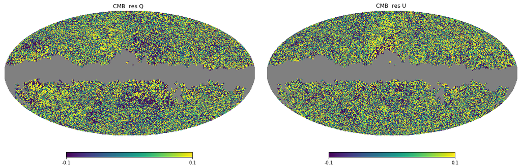

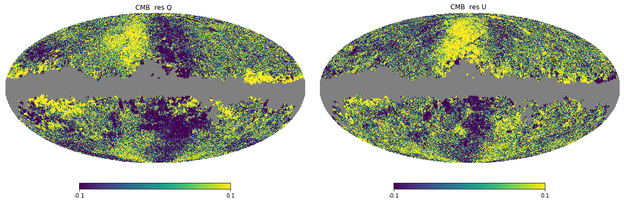

```python
pl.figure(figsize=(16,10 ))

hp.mollview(result.s[0,0] , title='CMB  res Q ', sub=(121), min=-0.1,max=0.1)
hp.mollview(result.s[0,1] , title='CMB  res U ', sub=(122), min=-0.1,max=0.1)
pl.figure(figsize=(16,10 ))

hp.mollview(resultconst.s[0,0] , title='CMB  res Q ', sub=(121), min=-0.1,max=0.1)
hp.mollview(resultconst.s[0,1] , title='CMB  res U ', sub=(122), min=-0.1,max=0.1)
```

**Fig5** (top)CMB QU map residuals post component sep. for the run performed with clustering patches at `nside=128`. (bottom) CMB QU map residuals post component sep. for the run at `nside=128` where one signle spectral parameter has been fitted.

```python
m = pl.zeros_like (freq_maps2[0])
mconst = pl.zeros_like (freq_maps2[0] )
for i in range(2):
    nan = pl.ma.masked_invalid ( result.s[0,i] ) .mask
    m[i+1,:] = result.s[0,i]
    m[i+1,nan] = hp.UNSEEN

    mconst[i+1,:] = resultconst .s[0,i]
clconst = hp.anafast(   mconst    ,lmax=3*nside2  )
cl = hp.anafast(m   ,lmax=3*nside2  )
ell=pl.arange(  cl.shape[1]   )
```

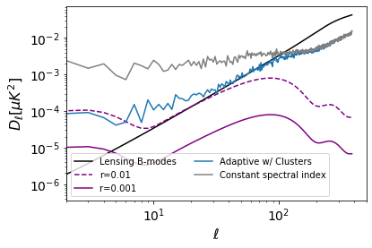

```python
clr = pl.loadtxt('/Users/peppe/work/satellite_sims/power_spectra/Class_planck2015_r0_cl_lensed.dat')
clr1 = pl.loadtxt('/Users/peppe/work/satellite_sims/power_spectra/Class_planck2015_r1_cl_unlensed.dat')
pl.loglog(ell, clr[ :ell.shape[0],3]*ell*( ell +1)/2./pl.pi   ,'k',label='Lensing B-modes'  )
pl.loglog(ell, clr1[ :ell.shape[0],3]*ell*( ell +1)/2./pl.pi /100.  ,'--',color='purple', label='r=0.01'  )
pl.loglog(ell, clr1[ :ell.shape[0],3]*ell*( ell +1)/2./pl.pi /1000.  ,color='purple',label='r=0.001 '  )
pl.loglog(ell, ell*( ell +1)/2./pl.pi* cl[2, :],  label = 'Adaptive w/ Clusters')

pl.loglog(ell, ell*( ell +1)/2./pl.pi* clconst[2, :], color='grey',  label='Constant spectral index')
pl.xlim(2, 500)
pl.ylabel(r'$D_{\ell}  [ \mu K^2 ]$', fontsize=16)
pl.xlabel(r'$ {\ell}   $', fontsize=16)
pl.yticks(fontsize=14)
pl.xticks(fontsize=14)

pl.legend(loc='best',ncol=2)
#pl.ylim(1e-7, 1e-2)
```

**Fig6** (solid blue) Power spectra of B-mode residuals post component separation performed with adaptive patches. (solid grey) B-mode residuals post-component separation fitting one spectr. parameter constant across the sky.